# ESM 204 HW 4: Calculating the SCC and policy choice under uncertainty

Larissa Neilson, Alison Sells, Katelyn Toigo

5/28/2021

```r
# Read in the data
damage <- read_csv(here("data", "damages.csv")) %>%
  clean_names()
warming <- read_csv(here("data", "warming.csv")) %>%
  clean_names()
```

1. Using damages.csv, estimate a quadratic damage function relating the dollar value of damages to the change in global mean temperature. Omit an intercept term; damages by construction must equal zero when there is no climate change. Plot your estimated damage function, overlaid with a scatterplot of the underlying data.

```r
# Question 1
damages <- damage %>%
  mutate(warming2 = warming^2)

# Quadratic model of damages
dam_lm <- lm(damages ~ warming + warming2, data = damages)
dam_lm[["coefficients"]][["(Intercept)"]] <- 0
dam_lm
```

```
##
## Call:
## lm(formula = damages ~ warming + warming2, data = damages)
##
## Coefficients:
## (Intercept)      warming     warming2
##   0.000e+00   -3.019e+12    1.959e+13
```

```r
# Damages Plot
damages_plot <- ggplot(data = damages) +
  geom_point(aes(x = warming, y = damages)) +
  stat_smooth(data = damages, aes(x = warming, y = damages)) +
  labs(x = "Level of warming (ºC)", y = "Annual total damages ($)") +
  theme_minimal()
#damages_plot
```

```r
# Function with our quadratic equation
damage_function <- function(warming) {
  damages <- (19590000000000 * warming^2) - (3019000000000 * warming)
  return(damages)
}

# Test
#damage_function(0.3022845)
```

2. Use warming.csv and your estimated damage function to predict damages in each year under the baseline climate and the pulse scenario. Make four plots: (1) damages over time without the pulse, (2) damages over time with the pulse, (3) the difference in damages over time that arises from the pulse, and (4) the difference in damages over time from the pulse per ton of CO2 (you can assume that each ton of the pulse causes the same amount of damage).

```r
# Test, this should input the same # as the last test line but it's slightly off?
#damage_function(warming[1, "warming_baseline"])

# This makes new column with the calculated damages using values from the warming_baseline column
warming$damage_base <- damage_function(warming$warming_baseline)
#head(warming$damage_base)

# Question 2 plot (1)
plot_baseline <- ggplot(data = warming, aes(x = year, y = damage_base)) +
  geom_point(cex = 0.5) +
  labs(x = "Year", y = "Total damages ($)", title = "Damages without Pulse") +
  theme_minimal()

# Do the same with values from the warming_pulse column
warming$damage_pulse <- damage_function(warming$warming_pulse)
#head(warming$damage_pulse)

# Question 2 plot (2)
plot_pulse <- ggplot(data = warming, aes(x = year, y = damage_pulse)) +
  geom_point(cex = 0.5) +
  labs(x = "Year", y = "Total damages ($)", title = "Damages with Pulse") +
  theme_minimal()
```

```r
warming_diff <- warming %>%
  mutate(damage_diff = (damage_pulse - damage_base))

# Question 2 plot (3)
plot_difference <- ggplot(data = warming_diff, aes(x = year, y = damage_diff)) +
  geom_point(cex = 0.5) +
  labs(x = "Year", y = "Difference in damage ($)", title = "Diff. in Damages with Pulse") +
  theme_minimal()
```

```r
# Question 2 Part 4
warming_diff_norm<- warming_diff %>%
  mutate(damage_diff_norm = damage_diff/ 35000000000)

# Question 2 plot (4)
plot_difference_per_ton <- ggplot(data = warming_diff_norm, aes(x = year, y = damage_diff_norm)) +
  geom_point(cex = 0.5) +
  labs(x = "Year", y = " Difference in damage ($ per ton)", title = "Diff. in Dmg. with Pulse/ton of CO2") +
  theme_minimal()
```

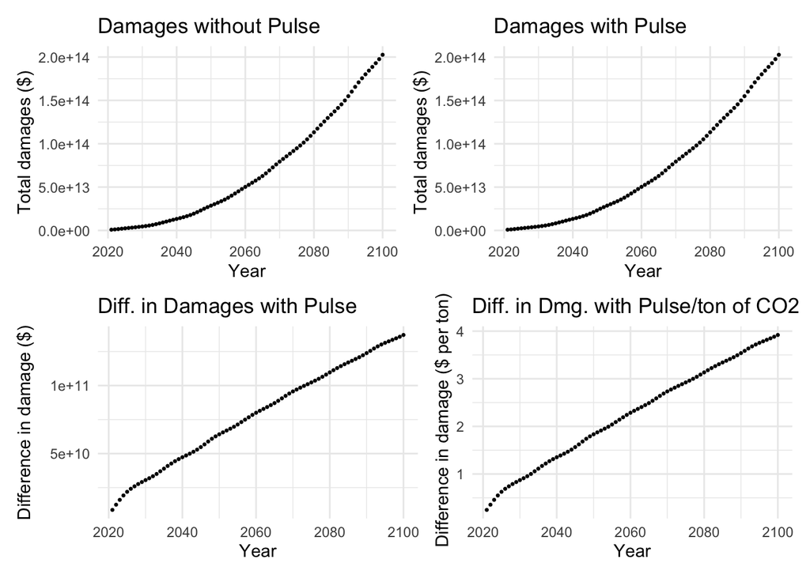

```r
# Use patchwork package
all_plots <- (plot_baseline + plot_pulse) / (plot_difference + plot_difference_per_ton)

all_plots
```

3. The SCC is the present discounted value of the stream of future damages caused by one additional ton of CO2. The Obama Administration used a discount rate of 3% to discount damages. Recently, New York State used a discount rate of 2%. Calculate and make a plot of the SCC (y-axis) against the discount rate (x-axis) for a reasonable range of discount rates.

```r
# Question 3
# Accounting for various discount rates
scc <- warming_diff_norm %>%
  mutate(scc_1 = damage_diff/ (1+0.01)^x1,
         scc_2 = damage_diff/ (1+0.02)^x1,
         scc_3 = damage_diff/ (1+0.03)^x1,
         scc_4 = damage_diff/ (1+0.04)^x1,
         scc_5 = damage_diff/ (1+0.05)^x1,
         scc1_sum = sum(scc_1),
         scc2_sum = sum(scc_2),
         scc3_sum = sum(scc_3),
         scc4_sum = sum(scc_4),
         scc5_sum = sum(scc_5))

scc_df <- data.frame(c(0.01, 0.02, 0.03, 0.04, 0.05)) %>%
  cbind(c(scc$scc1_sum[1], scc$scc2_sum[1], scc$scc3_sum[1], scc$scc4_sum[1], scc$scc5_sum[1]))
colnames(scc_df) <- c("rate", "scc_sum")
```

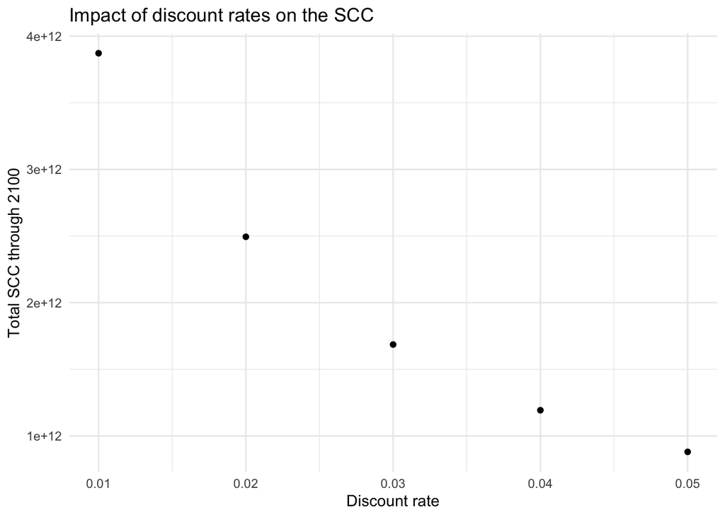

```r
ggplot(data = scc_df) +
  geom_point(aes(x = rate, y = scc_sum)) +
  labs(x = "Discount rate", y = "Total SCC through 2100", title = "Impact of discount rates on the SCC") +
  theme_minimal()
```

4. The National Academies of Sciences, Engineering, and Medicine advised the government in a 2017 report to use the Ramsey Rule when discounting within the SCC calculation: r = ρ + ηg Using ρ = 0.001, η = 2, and g = 0.01, what is the SCC? Locate this point on your graph from above.

```r
# Question 4
rams = 0.001 + (2*0.01) # new r value

scc<- warming_diff_norm %>%
  mutate(scc_rams = damage_diff/ (1 + rams)^x1,
          scc_rams_sum = sum(scc_rams))

scc_rams_df <- data.frame(c(0.021)) %>%
  cbind(c(scc$scc_rams_sum[1]))
colnames(scc_rams_df) <- c("rate", "scc_sum")
```

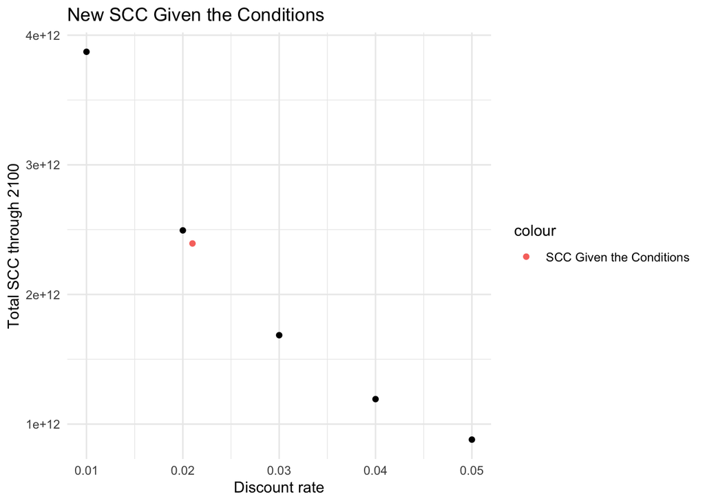

```r
# This line fixes the legend to be what we want the descriptor to say
cols <- c("New SCC" = "tomato2")

ggplot() +
  geom_point(data = scc_df,
             aes(x = rate, y = scc_sum)) +
  geom_point(data = scc_rams_df, aes(x = rate, y = scc_sum, color = "SCC Given the Conditions")) +
  theme(legend.title = element_blank()) +
  labs(x = "Discount rate", y = "Total SCC through 2100", title = "New SCC Given the Conditions") +
  theme_minimal()
```

5. Now suppose there are two possible climate policies that can be pursued. Policy A is business as usual and Policy B is to take immediate and strong action on climate change. Use these facts:
- If you undertake Policy A there are two possible outcomes. Either warming will occur as in the “baseline” (i.e. “no-pulse”) dataset above (this happens with probability 0.5) or warming each year will be 1.5 times that in the “baseline” dataset (with probability 0.5).
- Under Policy B, warming will continue until 2050 as in the “baseline” dataset, and then will stabilize at 1.29 degrees and stay that way forever.
- Society is risk neutral
- Use a discount rate of 2%
1. What is the expected present value of damages up to 2100 under Policy A? B)What is the expected present value of damages up to 2100 under Policy B? C)Suppose undertaking Policy D)A costs zero and undertaking Policy B costs X. How large could X be for it to still make economic sense to pursue Policy B instead of Policy A? E)Qualitatively, how would your answer change if society were risk averse?

```r
# Question 5
# Since There are two policy outcomes for A, we need to figure out the expected present value for each and multiply each potential outcome by their respective probabilities
warming_sub <- warming %>%
  select(x1,year, warming_baseline, damage_base)

prob_dam <- warming_sub %>%
  mutate(warming_1.5 = warming_baseline * 1.5)

prob_dam$damage_1.5 <- damage_function(prob_dam$warming_1.5)
#head(prob_dam$damage_1.5)

sum_prob_dam <- prob_dam %>%
  mutate(npv_1.5 = damage_1.5/ (1+0.02)^x1,
         npv_base = damage_base/ (1+0.02)^x1,
         sum_dam_1.5 = sum(npv_1.5),
         sum_dam_base = sum(npv_base),
         exp_value = ((sum_dam_1.5*0.5)+ (sum_dam_base*0.5)))
```

```r
warming5B <- warming %>%
  select(x1, year, warming_baseline) %>%
  mutate(warming = case_when(
    year < 2050 ~ warming_baseline,
    year >= 2050 ~ 1.29),
    dam_b = (warming*3019000000000) + ((warming)^2*19590000000000),
    dam_b_sc = dam_b/ (1+0.02)^x1)

warming_5b_sum <- warming5B %>%
 mutate(sum_b_sc = sum(dam_b_sc))
```

```r
# Cost of Policy A = Cost of Policy B + x
# Need to find how much x could be for it still to make sense to use Policy B

# Maximum of x for Policy B to still make sense
exp_value_calc_a <- sum_prob_dam %>%
  select(exp_value)

exp_value_calc_b <- warming_5b_sum %>%
  select(sum_b_sc)

max_price_x = (exp_value_calc_a - exp_value_calc_b)

#max_price_x
```